# Przepracowani i biedni - zależność między godzinami pracy a bogactwem narodu

Julia Dyrga, Rafał Klimek

2024-12-28

Sprawdzimy ilość przepracowanych godzin dla różnych krajów i przeciwstawimy je:

- PKB per capita - bardziej zaawansowane gospodarki będą mieć większe PKB (wziąłem też PPP)
- oczekiwanej długości życia
- Współczynnikowi Giniego
- zapisu na uczelnie wyższe

Dane będą analizowane dla 2010 roku

```r
countries <- c(
    "AR", "AM", "AT", "BE", "BG", "CO", "CZ", "DK", "DO", "EG",
    "EE", "FI", "FR", "GR", "HN", "HU", "IS", "ID", "IT", "JO",
    "LV", "LT", "LU", "MW", "MT", "MX", "MD", "MN", "NP", "NL",
    "NG", "NO", "PA", "PY", "PL", "RO", "SK", "SI", "ZA", "ES",
    "SE", "TH", "TN", "GB", "UY"
)

describing_indicators <- c(
    'gdp_per_capita' = 'NY.GDP.PCAP.CD',
    'gdp_per_capita_ppp' = 'NY.GDP.PCAP.PP.CD',
    'life_expectancy' = 'SP.DYN.LE00.IN',
    'income_inequality' = 'SI.POV.GINI',
    'enrollment_tetriary' = 'SE.TER.ENRR'
)
work_indicators <- c(
    'weekly_hours_worked_15_64' = 'JI.TLF.1564.WK.TM'
)

describing_data_2010 = WDI(country=countries, indicator=describing_indicators, start=2010, end=2010)
work_data_data_2010 = WDI(country=countries, indicator=work_indicators, start=2010, end=2010)
# data clearing
merged_data <- merge(describing_data_2010, work_data_data_2010, by="country")
null_cleared <- merged_data[complete.cases(merged_data), ] # I left an example of how I removed NULLs from my data sets
data <- null_cleared[c('country', 'gdp_per_capita', 'gdp_per_capita_ppp', 'life_expectancy', 'income_inequality', 'enrollment_tetriary', 'weekly_hours_worked_15_64')]
data_no_countries <- data[c('gdp_per_capita', 'gdp_per_capita_ppp', 'life_expectancy', 'income_inequality', 'enrollment_tetriary', 'weekly_hours_worked_15_64')]
```

# Summary

```r
summary(data_no_countries)
```

```
##  gdp_per_capita     gdp_per_capita_ppp life_expectancy income_inequality
##  Min.   :   585.3   Min.   : 1458      Min.   :50.95   Min.   :24.90
##  1st Qu.:  4918.1   1st Qu.:10880      1st Qu.:73.24   1st Qu.:29.30
##  Median : 12198.4   Median :18850      Median :75.58   Median :33.70
##  Mean   : 22079.9   Mean   :23631      Mean   :74.89   Mean   :35.75
##  3rd Qu.: 37038.3   3rd Qu.:35451      3rd Qu.:80.39   3rd Qu.:36.70
##  Max.   :110886.0   Max.   :90346      Max.   :82.04   Max.   :63.40
##  enrollment_tetriary weekly_hours_worked_15_64
##  Min.   :  0.7372    Min.   :31.84
##  1st Qu.: 37.5272    1st Qu.:38.88
##  Median : 58.1995    Median :40.21
##  Mean   : 54.1602    Mean   :40.88
##  3rd Qu.: 72.6418    3rd Qu.:42.66
##  Max.   :101.6941    Max.   :50.86
```

# Histogramy

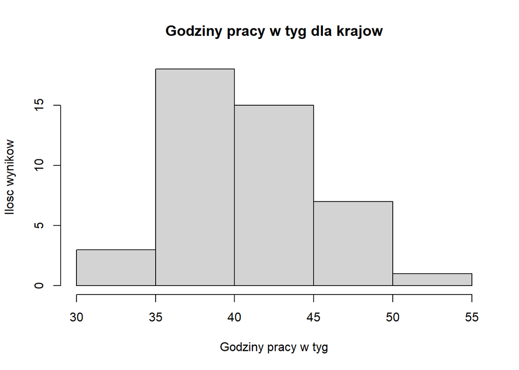

```r
hist(data_no_countries$weekly_hours_worked_15_64, breaks = 4, xlab = "Godziny pracy w tyg", ylab= "Ilosc wynikow",
     main = "Godziny pracy w tyg dla krajow")
```

Histogram wizualnie pokazuje mocne skupienie wokół średniej

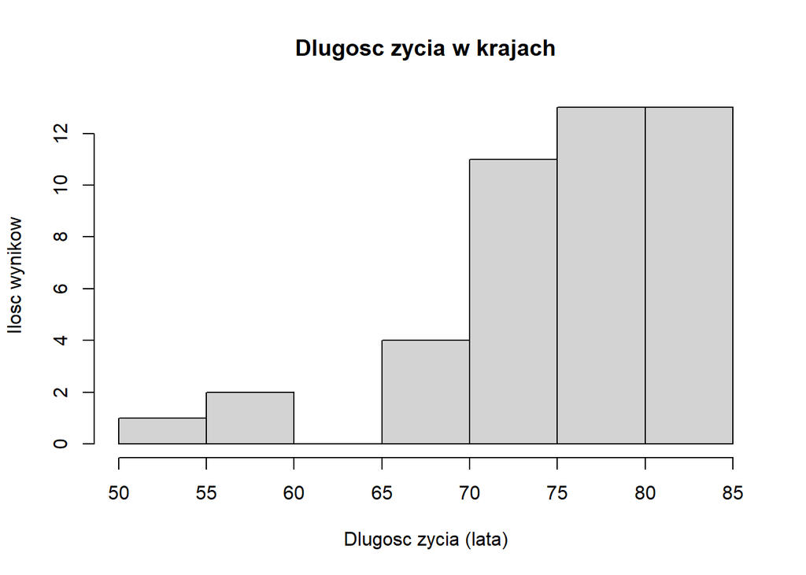

```r
hist(data_no_countries$life_expectancy, breaks = 6, xlab = "Dlugosc zycia (lata)", ylab= "Ilosc wynikow",
     main = "Dlugosc zycia w krajach")
```

Lewostronnie skośna długość życia.

# Korelacja

```r
cor(data_no_countries)
```

```
##                           gdp_per_capita gdp_per_capita_ppp life_expectancy
## gdp_per_capita                 1.0000000          0.9766256       0.5977567
## gdp_per_capita_ppp             0.9766256          1.0000000       0.6713719
## life_expectancy                0.5977567          0.6713719       1.0000000
## income_inequality             -0.4746026         -0.4991229      -0.4519471
## enrollment_tetriary            0.3190767          0.3899125       0.6697440
## weekly_hours_worked_15_64     -0.4724860         -0.4511812      -0.3368329
##                           income_inequality enrollment_tetriary
## gdp_per_capita                   -0.4746026           0.3190767
## gdp_per_capita_ppp               -0.4991229           0.3899125
## life_expectancy                  -0.4519471           0.6697440
## income_inequality                 1.0000000          -0.4919007
## enrollment_tetriary              -0.4919007           1.0000000
## weekly_hours_worked_15_64         0.2504280          -0.2292396
##                           weekly_hours_worked_15_64
## gdp_per_capita                           -0.4724860
## gdp_per_capita_ppp                       -0.4511812
## life_expectancy                          -0.3368329
## income_inequality                         0.2504280
## enrollment_tetriary                      -0.2292396
## weekly_hours_worked_15_64                 1.0000000
```

Jako, że analizujemy wpływ na godziny pracy, to najważniejszy jest dla nas ostatni wiersz widać tam, że jedyna pozytywna korelacja jest między nierównością dochodową, a godzinami pracy, im większa nierówność, tym więcej pracują.

Żaden współczynnik nie wskazuje na silna korelację (maksymalnie na umiarkowaną ~-0.4), ale wszystkie pozostałe wskaźniki potwierdzają tezę, że im bardziej rozwinięty kraj:

- (wyższe PKB per capita PPP),
- próba wyższej edukacji (większy enrollment rate może wskazywać także na bardziej opiekuńcze państwo)
- długość życia (aczkolwiek tu wpływ raczej ma praca na długość życia, nie na odwrót)

tym mniejsza ilość godzin pracy w tygodniu. Zgodnie z naszym założeniem.